# Data exploration with tidyverse

10 May 2018

## Preparing for this lecture

- All materials are on https://github.com/kevinwang09/MSH4_2018 and https://github.com/kevinwang09/2017_STAT3914.
- Some cheatsheets: https://www.rstudio.com/resources/cheatsheets/.
- There is an interactive tutorial on `ggplot2`. https://garthtarr.shinyapps.io/ggplot2_basic_tutorial/

```r
## Might be a while...
install.packages("tidyverse")
install.packages(c("ggplot2","dplyr", "readr","tidyr","janitor","plotly",
                   "devtools","learnr","gapminder", "e1071"))
```

## Why am I here?

- I served at the commands of Jean.
- Everything I am telling you today has an equivalent solution in base `R`.
- So why am I even here?

## What is the aim of this lecture?

- Certain tasks in `R` used to be very difficult. Especially data cleaning and manipulations.
- For example, how would you calculate the mean of `Sepal.Length`, `Sepal.Width`, `Petal.Length`, `Petal.Width` in the `iris` dataset?

```r
head(iris, 3)
```

```
##   Sepal.Length Sepal.Width Petal.Length Petal.Width Species
## 1          5.1         3.5          1.4         0.2  setosa
## 2          4.9         3.0          1.4         0.2  setosa
## 3          4.7         3.2          1.3         0.2  setosa
```

```r
mean(iris$Sepal.Length)
```

```
## [1] 5.843333
```

```r
mean(iris$Sepal.Width)
```

```
## [1] 3.057333
```

- I am too lazy to type… But I think you get the idea…

## What about the grouped means?

- Dear me… This is too much typing!!

```r
tapply(iris$Sepal.Length, iris$Species, mean)
```

```
##     setosa versicolor  virginica
##      5.006      5.936      6.588
```

```r
tapply(iris$Sepal.Width, iris$Species, mean)
```

```
##     setosa versicolor  virginica
##      3.428      2.770      2.974
```

## You are not alone in hating all these typing!

```r
iris %>%
  summarise_if(is.numeric, mean)
```

```
##   Sepal.Length Sepal.Width Petal.Length Petal.Width
## 1     5.843333    3.057333        3.758    1.199333
```

- To caluclate grouped mean: identical to before, but we need to apply the mean to the `Species` grouping first!

```r
iris %>%
  group_by(Species) %>%
  summarise_if(is.numeric, mean)
```

```
## # A tibble: 3 x 5
##   Species    Sepal.Length Sepal.Width Petal.Length Petal.Width
##   <fct>             <dbl>       <dbl>        <dbl>       <dbl>
## 1 setosa             5.01        3.43         1.46       0.246
## 2 versicolor         5.94        2.77         4.26       1.33
## 3 virginica          6.59        2.97         5.55       2.03
```

## `tidyverse` is a collection of packages

- Reading in data using `readr` and `readxl`
- Better than data.frame: `tibble`
- Basic data cleaning using `janitor`
- Clean coding using `magrittr`
- Data filtering using `dplyr`
- Data visualisation using `ggplot2`

## Reading in data

## `readr` for basic data types and `readxl` for .xlsx files

- I know some of you are using this already.
- Parsing warnings.
- NEVER read in factors.

```r
rawEyData = read_csv("EY-data-science-challenge-pack/train.csv",
                     guess_max = 10, ## use the first 10 rows to guess the variable type
                     progress = TRUE ## If the data is large, a progress bar will be shown
)
```

## tibble

## `tibble` is more advanced data.frame

- There is a super advanced way of using `tibble`, see another set of slides.

```r
class(rawEyData)
```

```
## [1] "tbl_df"     "tbl"        "data.frame"
```

```r
rawEyData
```

```
## # A tibble: 1,010 x 41
##      id LOCATION  TIME GENDER `Population (% … EDU_TERTIARY_PC… CPI_AGRWTH
##   <int> <chr>    <int> <chr>             <dbl>            <dbl>      <dbl>
## 1     1 AUS       1993 MEN                49.8             23.5       1.75
## 2     2 AUS       1993 WOMEN              50.2             21.4       1.75
## 3     3 AUS       1994 MEN                49.8             24.4       1.97
## 4     4 AUS       1994 WOMEN              50.2             21.7       1.97
## 5     5 AUS       1995 MEN                49.8             25.8       4.63
## # ... with 1,005 more rows, and 34 more variables: GDP_USD_CAP <dbl>,
## #   GOV_SPEND_EDU <dbl>, `%_Sanitation_Access` <int>, `Access to Clean
## #   Fuels and Technologies for cooking (% of total population)
## #   [2.1_ACCESS.CFT.TOT]` <chr>, `Access to electricity (% of rural
## #   population with access) [1.2_ACCESS.ELECTRICITY.RURAL]` <int>, `Access
## #   to electricity (% of total population)
## #   [1.1_ACCESS.ELECTRICITY.TOT]` <int>, `Access to electricity (% of
## #   urban population with access) [1.3_ACCESS.ELECTRICITY.URBAN]` <int>,
## #   `Energy intensity level of primary energy (MJ/2011 USD PPP)
## #   [6.1_PRIMARY.ENERGY.INTENSITY]` <dbl>, `Renewable electricity output
## #   (GWh) [4.1.2_REN.ELECTRICITY.OUTPUT]` <int>, `Renewable electricity
## #   share of total electricity output (%)
## #   [4.1_SHARE.RE.IN.ELECTRICITY]` <dbl>, `Renewable energy consumption
## #   (TJ) [3.1_RE.CONSUMPTION]` <dbl>, `Renewable energy share of TFEC (%)
## #   [2.1_SHARE.TOTAL.RE.IN.TFEC]` <dbl>, `Total electricity output (GWh)
## #   [4.1.1_TOTAL.ELECTRICITY.OUTPUT]` <int>, `Total final energy
## #   consumption (TFEC) (TJ) [1.1_TOTAL.FINAL.ENERGY.CONSUM]` <dbl>,
## #   `Population ages 00-04 (as % of specified gender population)` <dbl>,
## #   `Population ages 05-09 (as % of specified gender population)` <dbl>,
## #   `Population ages 10-14 (as % of specified gender population)` <dbl>,
## #   `Population ages 15-19 (as % of specified gender population)` <dbl>,
## #   `Population ages 20-24 (as % of specified gender population)` <dbl>,
## #   `Population ages 25-29 (as % of specified gender population)` <dbl>,
## #   `Population ages 30-34 (as % of specified gender population)` <dbl>,
## #   `Population ages 35-39 (as % of specified gender population)` <dbl>,
## #   `Population ages 40-44 (as % of specified gender population)` <dbl>,
## #   `Population ages 45-49 (as % of specified gender population)` <dbl>,
## #   `Population ages 50-54 (as % of specified gender population)` <dbl>,
## #   `Population ages 55-59 (as % of specified gender population)` <dbl>,
## #   `Population ages 60-64 (as % of specified gender population)` <dbl>,
## #   `Population ages 65-69 (as % of specified gender population)` <dbl>,
## #   `Population ages 70-74 (as % of specified gender population)` <dbl>,
## #   `Population ages 75-79 (as % of specified gender population)` <dbl>,
## #   `Population ages 80 and older (as % of specified gender
## #   population)` <dbl>, TER_Enrolment_rate <dbl>, `GNI per capita, Atlas
## #   method (current US$)` <int>, Quality_of_life_measure <dbl>
```

## Janitor

## Consistent naming of columns

- This is perhaps the most useful function in `janitor`.

```r
eyData = janitor::clean_names(rawEyData)
eyData
```

```
## # A tibble: 1,010 x 41
##      id location  time gender population_perc… edu_tertiary_pc… cpi_agrwth
##   <int> <chr>    <int> <chr>             <dbl>            <dbl>      <dbl>
## 1     1 AUS       1993 MEN                49.8             23.5       1.75
## 2     2 AUS       1993 WOMEN              50.2             21.4       1.75
## 3     3 AUS       1994 MEN                49.8             24.4       1.97
## 4     4 AUS       1994 WOMEN              50.2             21.7       1.97
## 5     5 AUS       1995 MEN                49.8             25.8       4.63
## # ... with 1,005 more rows, and 34 more variables: gdp_usd_cap <dbl>,
## #   gov_spend_edu <dbl>, percent_sanitation_access <int>,
## #   access_to_clean_fuels_and_technologies_for_cooking_percent_of_total_population_2_1_access_cft_tot <chr>,
## #   access_to_electricity_percent_of_rural_population_with_access_1_2_access_electricity_rural <int>,
## #   access_to_electricity_percent_of_total_population_1_1_access_electricity_tot <int>,
## #   access_to_electricity_percent_of_urban_population_with_access_1_3_access_electricity_urban <int>,
## #   energy_intensity_level_of_primary_energy_mj_2011_usd_ppp_6_1_primary_energy_intensity <dbl>,
## #   renewable_electricity_output_g_wh_4_1_2_ren_electricity_output <int>,
## #   renewable_electricity_share_of_total_electricity_output_percent_4_1_share_re_in_electricity <dbl>,
## #   renewable_energy_consumption_tj_3_1_re_consumption <dbl>,
## #   renewable_energy_share_of_tfec_percent_2_1_share_total_re_in_tfec <dbl>,
## #   total_electricity_output_g_wh_4_1_1_total_electricity_output <int>,
## #   total_final_energy_consumption_tfec_tj_1_1_total_final_energy_consum <dbl>,
## #   population_ages_00_04_as_percent_of_specified_gender_population <dbl>,
## #   population_ages_05_09_as_percent_of_specified_gender_population <dbl>,
## #   population_ages_10_14_as_percent_of_specified_gender_population <dbl>,
## #   population_ages_15_19_as_percent_of_specified_gender_population <dbl>,
## #   population_ages_20_24_as_percent_of_specified_gender_population <dbl>,
## #   population_ages_25_29_as_percent_of_specified_gender_population <dbl>,
## #   population_ages_30_34_as_percent_of_specified_gender_population <dbl>,
## #   population_ages_35_39_as_percent_of_specified_gender_population <dbl>,
## #   population_ages_40_44_as_percent_of_specified_gender_population <dbl>,
## #   population_ages_45_49_as_percent_of_specified_gender_population <dbl>,
## #   population_ages_50_54_as_percent_of_specified_gender_population <dbl>,
## #   population_ages_55_59_as_percent_of_specified_gender_population <dbl>,
## #   population_ages_60_64_as_percent_of_specified_gender_population <dbl>,
## #   population_ages_65_69_as_percent_of_specified_gender_population <dbl>,
## #   population_ages_70_74_as_percent_of_specified_gender_population <dbl>,
## #   population_ages_75_79_as_percent_of_specified_gender_population <dbl>,
## #   population_ages_80_and_older_as_percent_of_specified_gender_population <dbl>,
## #   ter_enrolment_rate <dbl>,
## #   gni_per_capita_atlas_method_current_us <int>,
## #   quality_of_life_measure <dbl>
```

## Tabulate in style

- Sometimes you want to calculate counts as well as percentages.

```r
eyData %>%
  janitor::tabyl(location, gender) %>%
  janitor::adorn_percentages() %>%
  janitor::adorn_ns()
```

```
##  location      MEN    WOMEN
##       AUS 0.5 (23) 0.5 (23)
##       AUT 0.5 (18) 0.5 (18)
##       BEL 0.5 (18) 0.5 (18)
##       CAN 0.5 (22) 0.5 (22)
##       CHL 0.5 (11) 0.5 (11)
##       COL 0.5 (10) 0.5 (10)
##       CZE 0.5 (19) 0.5 (19)
##       DEU 0.5 (12) 0.5 (12)
##       DNK 0.5 (18) 0.5 (18)
##       ESP 0.5 (18) 0.5 (18)
##       EST 0.5 (17) 0.5 (17)
##       FIN 0.5 (19) 0.5 (19)
##       GBR 0.5 (17) 0.5 (17)
##       HUN 0.5 (18) 0.5 (18)
##       IRL 0.5 (16) 0.5 (16)
##       ISL 0.5 (14) 0.5 (14)
##       ISR 0.5 (22) 0.5 (22)
##       ITA 0.5 (19) 0.5 (19)
##       JPN 0.5 (24) 0.5 (24)
##       KOR 0.5 (17) 0.5 (17)
##       LUX 0.5 (14) 0.5 (14)
##       LVA 0.5 (15) 0.5 (15)
##       NLD 0.5 (17) 0.5 (17)
##       POL 0.5 (17) 0.5 (17)
##       PRT 0.5 (19) 0.5 (19)
##       SVK 0.5 (18) 0.5 (18)
##       SVN 0.5 (18) 0.5 (18)
##       SWE 0.5 (16) 0.5 (16)
##       TUR 0.5 (11) 0.5 (11)
##       ZAF 0.5  (8) 0.5  (8)
```

## Magrittr

## `base` R coding: read from inside the brackets

- It can get messy very quickly.
- WORSE: You might not know what you are doing if you are not paying attention!

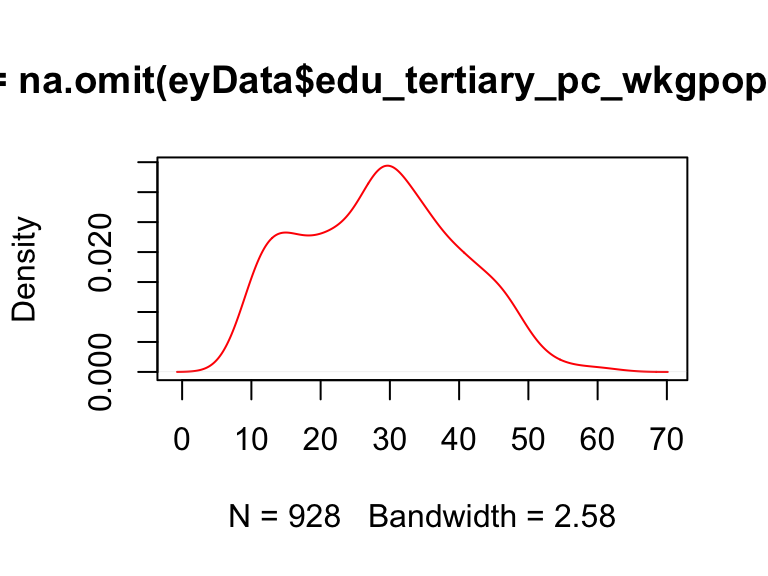

```r
plot(density(na.omit(eyData$edu_tertiary_pc_wkgpop), kernel = "gaussian"), col = "red")
```

## Piping `%>%` is about making your code readable to humans

- **`base`**: `f(x)` means applying `f` on an object, `x`.
- **`magrittr`**: `x %>% f` means starting off with an object `x` and apply `f` upon it.
- Allows people to read codes from left to right.
- Each function's option is within the righ bracket.

```r
mean(eyData$edu_tertiary_pc_wkgpop, na.rm = TRUE)
```

```
## [1] 28.58831
```

```r
eyData$edu_tertiary_pc_wkgpop %>%
  mean(na.rm = TRUE)
```

```
## [1] 28.58831
```

## The use of the `.`

- The `.` is a placeholder for everything before the pipe.
- It allows you to specify how and where the previous inputs should be used

```r
args(rnorm)
```

```
## function (n, mean = 0, sd = 1)
## NULL
```

```r
5 %>% rnorm(n = .)
```

```
## [1] -0.6264538  0.1836433 -0.8356286  1.5952808  0.3295078
```

```r
5 %>% rnorm(n = 1, mean = .)
```

```
## [1] 4.179532
```

## The density plot revisited

- It is **identical** to the previous density plot, but now it is much more readable for a human!

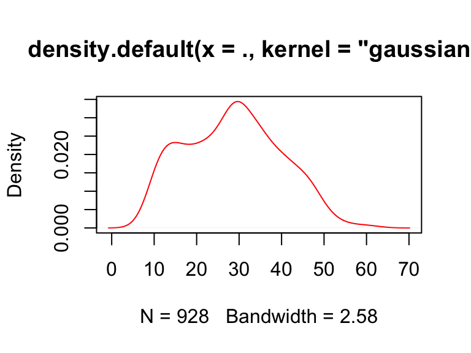

```r
eyData$edu_tertiary_pc_wkgpop %>%
  na.omit %>%
  density(kernel = "gaussian") %>%
  plot(col = "red")
```

## `dplyr`

## Have you ever thought about `[,]`?

- `base` R use `[,]` to subset data.
- But if you really think about it, why are we using the one symbol for two operations (**row**, **column**)?

```r
eyData[,c("id", "location")]
```

```
## # A tibble: 1,010 x 2
##      id location
##   <int> <chr>
## 1     1 AUS
## 2     2 AUS
## 3     3 AUS
## 4     4 AUS
## 5     5 AUS
## # ... with 1,005 more rows
```

```r
eyData[eyData$location == "AUS",]
```

```
## # A tibble: 46 x 41
##      id location  time gender population_perc… edu_tertiary_pc… cpi_agrwth
##   <int> <chr>    <int> <chr>             <dbl>            <dbl>      <dbl>
## 1     1 AUS       1993 MEN                49.8             23.5       1.75
## 2     2 AUS       1993 WOMEN              50.2             21.4       1.75
## 3     3 AUS       1994 MEN                49.8             24.4       1.97
## 4     4 AUS       1994 WOMEN              50.2             21.7       1.97
## 5     5 AUS       1995 MEN                49.8             25.8       4.63
## # ... with 41 more rows, and 34 more variables: gdp_usd_cap <dbl>,
## #   gov_spend_edu <dbl>, percent_sanitation_access <int>,
## #   access_to_clean_fuels_and_technologies_for_cooking_percent_of_total_population_2_1_access_cft_tot <chr>,
## #   access_to_electricity_percent_of_rural_population_with_access_1_2_access_electricity_rural <int>,
## #   access_to_electricity_percent_of_total_population_1_1_access_electricity_tot <int>,
## #   access_to_electricity_percent_of_urban_population_with_access_1_3_access_electricity_urban <int>,
## #   energy_intensity_level_of_primary_energy_mj_2011_usd_ppp_6_1_primary_energy_intensity <dbl>,
## #   renewable_electricity_output_g_wh_4_1_2_ren_electricity_output <int>,
## #   renewable_electricity_share_of_total_electricity_output_percent_4_1_share_re_in_electricity <dbl>,
## #   renewable_energy_consumption_tj_3_1_re_consumption <dbl>,
## #   renewable_energy_share_of_tfec_percent_2_1_share_total_re_in_tfec <dbl>,
## #   total_electricity_output_g_wh_4_1_1_total_electricity_output <int>,
## #   total_final_energy_consumption_tfec_tj_1_1_total_final_energy_consum <dbl>,
## #   population_ages_00_04_as_percent_of_specified_gender_population <dbl>,
## #   population_ages_05_09_as_percent_of_specified_gender_population <dbl>,
## #   population_ages_10_14_as_percent_of_specified_gender_population <dbl>,
## #   population_ages_15_19_as_percent_of_specified_gender_population <dbl>,
## #   population_ages_20_24_as_percent_of_specified_gender_population <dbl>,
## #   population_ages_25_29_as_percent_of_specified_gender_population <dbl>,
## #   population_ages_30_34_as_percent_of_specified_gender_population <dbl>,
## #   population_ages_35_39_as_percent_of_specified_gender_population <dbl>,
## #   population_ages_40_44_as_percent_of_specified_gender_population <dbl>,
## #   population_ages_45_49_as_percent_of_specified_gender_population <dbl>,
## #   population_ages_50_54_as_percent_of_specified_gender_population <dbl>,
## #   population_ages_55_59_as_percent_of_specified_gender_population <dbl>,
## #   population_ages_60_64_as_percent_of_specified_gender_population <dbl>,
## #   population_ages_65_69_as_percent_of_specified_gender_population <dbl>,
## #   population_ages_70_74_as_percent_of_specified_gender_population <dbl>,
## #   population_ages_75_79_as_percent_of_specified_gender_population <dbl>,
## #   population_ages_80_and_older_as_percent_of_specified_gender_population <dbl>,
## #   ter_enrolment_rate <dbl>,
## #   gni_per_capita_atlas_method_current_us <int>,
## #   quality_of_life_measure <dbl>
```

## `dplyr` is a super way to manipulate your data

- Think of subsetting rows and columns as two **separate different procedures**:
- `select` columns are operations on variables, and
- `filter` rows are operations on observations

```r
eyData %>% select(id, location)
```

```
## # A tibble: 1,010 x 2
##      id location
##   <int> <chr>
## 1     1 AUS
## 2     2 AUS
## 3     3 AUS
## 4     4 AUS
## 5     5 AUS
## # ... with 1,005 more rows
```

```r
eyData %>% filter(location == "AUS")
```

```
## # A tibble: 46 x 41
##      id location  time gender population_perc… edu_tertiary_pc… cpi_agrwth
##   <int> <chr>    <int> <chr>             <dbl>            <dbl>      <dbl>
## 1     1 AUS       1993 MEN                49.8             23.5       1.75
## 2     2 AUS       1993 WOMEN              50.2             21.4       1.75
## 3     3 AUS       1994 MEN                49.8             24.4       1.97
## 4     4 AUS       1994 WOMEN              50.2             21.7       1.97
## 5     5 AUS       1995 MEN                49.8             25.8       4.63
## # ... with 41 more rows, and 34 more variables: gdp_usd_cap <dbl>,
## #   gov_spend_edu <dbl>, percent_sanitation_access <int>,
## #   access_to_clean_fuels_and_technologies_for_cooking_percent_of_total_population_2_1_access_cft_tot <chr>,
## #   access_to_electricity_percent_of_rural_population_with_access_1_2_access_electricity_rural <int>,
## #   access_to_electricity_percent_of_total_population_1_1_access_electricity_tot <int>,
## #   access_to_electricity_percent_of_urban_population_with_access_1_3_access_electricity_urban <int>,
## #   energy_intensity_level_of_primary_energy_mj_2011_usd_ppp_6_1_primary_energy_intensity <dbl>,
## #   renewable_electricity_output_g_wh_4_1_2_ren_electricity_output <int>,
## #   renewable_electricity_share_of_total_electricity_output_percent_4_1_share_re_in_electricity <dbl>,
## #   renewable_energy_consumption_tj_3_1_re_consumption <dbl>,
## #   renewable_energy_share_of_tfec_percent_2_1_share_total_re_in_tfec <dbl>,
## #   total_electricity_output_g_wh_4_1_1_total_electricity_output <int>,
## #   total_final_energy_consumption_tfec_tj_1_1_total_final_energy_consum <dbl>,
## #   population_ages_00_04_as_percent_of_specified_gender_population <dbl>,
## #   population_ages_05_09_as_percent_of_specified_gender_population <dbl>,
## #   population_ages_10_14_as_percent_of_specified_gender_population <dbl>,
## #   population_ages_15_19_as_percent_of_specified_gender_population <dbl>,
## #   population_ages_20_24_as_percent_of_specified_gender_population <dbl>,
## #   population_ages_25_29_as_percent_of_specified_gender_population <dbl>,
## #   population_ages_30_34_as_percent_of_specified_gender_population <dbl>,
## #   population_ages_35_39_as_percent_of_specified_gender_population <dbl>,
## #   population_ages_40_44_as_percent_of_specified_gender_population <dbl>,
## #   population_ages_45_49_as_percent_of_specified_gender_population <dbl>,
## #   population_ages_50_54_as_percent_of_specified_gender_population <dbl>,
## #   population_ages_55_59_as_percent_of_specified_gender_population <dbl>,
## #   population_ages_60_64_as_percent_of_specified_gender_population <dbl>,
## #   population_ages_65_69_as_percent_of_specified_gender_population <dbl>,
## #   population_ages_70_74_as_percent_of_specified_gender_population <dbl>,
## #   population_ages_75_79_as_percent_of_specified_gender_population <dbl>,
## #   population_ages_80_and_older_as_percent_of_specified_gender_population <dbl>,
## #   ter_enrolment_rate <dbl>,
## #   gni_per_capita_atlas_method_current_us <int>,
## #   quality_of_life_measure <dbl>
```

## So what??

- Sure, you could stick with the `base` command.
- But sometimes, you realise that you could do something more powerful! (Notice how this would require a `for` loop or saving intermediate variables to achieve in `base`).

```r
eyData %>%
  filter(location == "AUS") %>%
  select(contains("population_ages"))
```

```
## # A tibble: 46 x 17
##   population_ages_0… population_ages_… population_ages_… population_ages_…
##                <dbl>             <dbl>             <dbl>             <dbl>
## 1               7.48              7.53              7.38              7.67
## 2               7.05              7.10              6.95              7.26
## 3               7.48              7.45              7.40              7.43
## 4               7.04              7.03              6.97              7.01
## 5               7.44              7.39              7.40              7.27
## # ... with 41 more rows, and 13 more variables:
## #   population_ages_20_24_as_percent_of_specified_gender_population <dbl>,
## #   population_ages_25_29_as_percent_of_specified_gender_population <dbl>,
## #   population_ages_30_34_as_percent_of_specified_gender_population <dbl>,
## #   population_ages_35_39_as_percent_of_specified_gender_population <dbl>,
## #   population_ages_40_44_as_percent_of_specified_gender_population <dbl>,
## #   population_ages_45_49_as_percent_of_specified_gender_population <dbl>,
## #   population_ages_50_54_as_percent_of_specified_gender_population <dbl>,
## #   population_ages_55_59_as_percent_of_specified_gender_population <dbl>,
## #   population_ages_60_64_as_percent_of_specified_gender_population <dbl>,
## #   population_ages_65_69_as_percent_of_specified_gender_population <dbl>,
## #   population_ages_70_74_as_percent_of_specified_gender_population <dbl>,
## #   population_ages_75_79_as_percent_of_specified_gender_population <dbl>,
## #   population_ages_80_and_older_as_percent_of_specified_gender_population <dbl>
```

## `mutate`

- How would you add in an extra column in a data?
- And what if you want to add in a second column that is a transformation of the first column?

```r
eyData$gdp_aud_cap = eyData$gdp_usd_cap * 0.75
eyData$gdp_aud_cap_billions = eyData$gdp_aud_cap/1000
```

- `mutate` allows you to do this in one function!

```r
eyData %>%
  mutate(
    gdp_aud_cap = gdp_usd_cap*0.75,
    gdp_aud_cap_billions = gdp_aud_cap/1000
  )
```

```
## # A tibble: 1,010 x 43
##      id location  time gender population_perc… edu_tertiary_pc… cpi_agrwth
##   <int> <chr>    <int> <chr>             <dbl>            <dbl>      <dbl>
## 1     1 AUS       1993 MEN                49.8             23.5       1.75
## 2     2 AUS       1993 WOMEN              50.2             21.4       1.75
## 3     3 AUS       1994 MEN                49.8             24.4       1.97
## 4     4 AUS       1994 WOMEN              50.2             21.7       1.97
## 5     5 AUS       1995 MEN                49.8             25.8       4.63
## # ... with 1,005 more rows, and 36 more variables: gdp_usd_cap <dbl>,
## #   gov_spend_edu <dbl>, percent_sanitation_access <int>,
## #   access_to_clean_fuels_and_technologies_for_cooking_percent_of_total_population_2_1_access_cft_tot <chr>,
## #   access_to_electricity_percent_of_rural_population_with_access_1_2_access_electricity_rural <int>,
## #   access_to_electricity_percent_of_total_population_1_1_access_electricity_tot <int>,
## #   access_to_electricity_percent_of_urban_population_with_access_1_3_access_electricity_urban <int>,
## #   energy_intensity_level_of_primary_energy_mj_2011_usd_ppp_6_1_primary_energy_intensity <dbl>,
## #   renewable_electricity_output_g_wh_4_1_2_ren_electricity_output <int>,
## #   renewable_electricity_share_of_total_electricity_output_percent_4_1_share_re_in_electricity <dbl>,
## #   renewable_energy_consumption_tj_3_1_re_consumption <dbl>,
## #   renewable_energy_share_of_tfec_percent_2_1_share_total_re_in_tfec <dbl>,
## #   total_electricity_output_g_wh_4_1_1_total_electricity_output <int>,
## #   total_final_energy_consumption_tfec_tj_1_1_total_final_energy_consum <dbl>,
## #   population_ages_00_04_as_percent_of_specified_gender_population <dbl>,
## #   population_ages_05_09_as_percent_of_specified_gender_population <dbl>,
## #   population_ages_10_14_as_percent_of_specified_gender_population <dbl>,
## #   population_ages_15_19_as_percent_of_specified_gender_population <dbl>,
## #   population_ages_20_24_as_percent_of_specified_gender_population <dbl>,
## #   population_ages_25_29_as_percent_of_specified_gender_population <dbl>,
## #   population_ages_30_34_as_percent_of_specified_gender_population <dbl>,
## #   population_ages_35_39_as_percent_of_specified_gender_population <dbl>,
## #   population_ages_40_44_as_percent_of_specified_gender_population <dbl>,
## #   population_ages_45_49_as_percent_of_specified_gender_population <dbl>,
## #   population_ages_50_54_as_percent_of_specified_gender_population <dbl>,
## #   population_ages_55_59_as_percent_of_specified_gender_population <dbl>,
## #   population_ages_60_64_as_percent_of_specified_gender_population <dbl>,
## #   population_ages_65_69_as_percent_of_specified_gender_population <dbl>,
## #   population_ages_70_74_as_percent_of_specified_gender_population <dbl>,
## #   population_ages_75_79_as_percent_of_specified_gender_population <dbl>,
## #   population_ages_80_and_older_as_percent_of_specified_gender_population <dbl>,
## #   ter_enrolment_rate <dbl>,
## #   gni_per_capita_atlas_method_current_us <int>,
## #   quality_of_life_measure <dbl>, gdp_aud_cap <dbl>,
## #   gdp_aud_cap_billions <dbl>
```

## Summarise

- Similar to `tapply`, but more flexible

```r
eyData %>%
  group_by(location) %>%
  summarise(
    medianQol = median(quality_of_life_measure),
    meanQol = mean(quality_of_life_measure)
  )
```

```
## # A tibble: 30 x 3
##   location medianQol meanQol
##   <chr>        <dbl>   <dbl>
## 1 AUS          0.239   0.231
## 2 AUT          0.580   0.578
## 3 BEL          0.523   0.516
## 4 CAN          0.522   0.523
## 5 CHL          0.546   0.537
## # ... with 25 more rows
```

```r
eyData %>%
  group_by(location, time) %>%
  summarise(medianQol = median(quality_of_life_measure))
```

```
## # A tibble: 505 x 3
## # Groups:   location [?]
##   location  time medianQol
##   <chr>    <int>     <dbl>
## 1 AUS       1993     0.205
## 2 AUS       1994     0.206
## 3 AUS       1995     0.206
## 4 AUS       1997     0.207
## 5 AUS       1998     0.206
## # ... with 500 more rows
```

## `ggplot2`

## I can't explain to you how to do a ggplot, you must learn it

- *gg* stands for grammar of graphics. Which means, there is a consistent way to produce a graph.
- Advice through pain and tears: use `base` graphs if you can get it working very quickly (e.g. scatter plot or boxplot). Use `ggplot2` if your graph will inevitabily get complex.
- Legend!!!

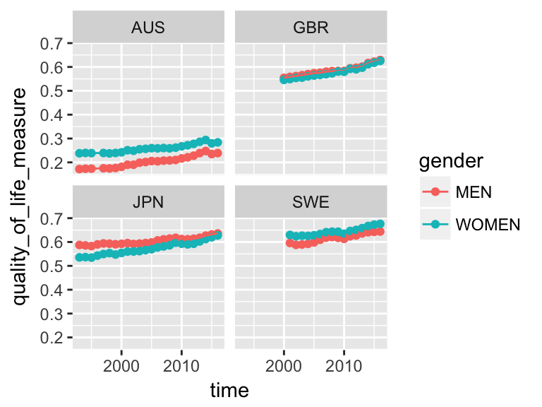

```r
eyData %>%
  filter(location %in% c("AUS", "GBR", "SWE", "JPN")) %>%
  ggplot(aes(x = time,
             y = quality_of_life_measure,
             colour = gender)) +
  geom_point() +
  geom_line() +
  facet_wrap(~location, nrow = 2)
```

## `tidyr`

## `tidyr` is a great companion with `ggplot2`

- I know some of you used `reshape2::melt`. Which is a special case of `tidyr::gather`. The latter offers more control

```r
popAges = eyData %>%
  select(location, contains("population_ages"))

popAges
```

```
## # A tibble: 1,010 x 18
##   location population_ages_00_0… population_ages_05_… population_ages_10_…
##   <chr>                    <dbl>                <dbl>                <dbl>
## 1 AUS                       7.48                 7.53                 7.38
## 2 AUS                       7.05                 7.10                 6.95
## 3 AUS                       7.48                 7.45                 7.40
## 4 AUS                       7.04                 7.03                 6.97
## 5 AUS                       7.44                 7.39                 7.40
## # ... with 1,005 more rows, and 14 more variables:
## #   population_ages_15_19_as_percent_of_specified_gender_population <dbl>,
## #   population_ages_20_24_as_percent_of_specified_gender_population <dbl>,
## #   population_ages_25_29_as_percent_of_specified_gender_population <dbl>,
## #   population_ages_30_34_as_percent_of_specified_gender_population <dbl>,
## #   population_ages_35_39_as_percent_of_specified_gender_population <dbl>,
## #   population_ages_40_44_as_percent_of_specified_gender_population <dbl>,
## #   population_ages_45_49_as_percent_of_specified_gender_population <dbl>,
## #   population_ages_50_54_as_percent_of_specified_gender_population <dbl>,
## #   population_ages_55_59_as_percent_of_specified_gender_population <dbl>,
## #   population_ages_60_64_as_percent_of_specified_gender_population <dbl>,
## #   population_ages_65_69_as_percent_of_specified_gender_population <dbl>,
## #   population_ages_70_74_as_percent_of_specified_gender_population <dbl>,
## #   population_ages_75_79_as_percent_of_specified_gender_population <dbl>,
## #   population_ages_80_and_older_as_percent_of_specified_gender_population <dbl>
```

```r
popAges %>%
  tidyr::gather(key = populationAgeGroups,
                value = percentage,
                -location)
```

```
## # A tibble: 17,170 x 3
##   location populationAgeGroups                                  percentage
##   <chr>    <chr>                                                     <dbl>
## 1 AUS      population_ages_00_04_as_percent_of_specified_gende…       7.48
## 2 AUS      population_ages_00_04_as_percent_of_specified_gende…       7.05
## 3 AUS      population_ages_00_04_as_percent_of_specified_gende…       7.48
## 4 AUS      population_ages_00_04_as_percent_of_specified_gende…       7.04
## 5 AUS      population_ages_00_04_as_percent_of_specified_gende…       7.44
## # ... with 1.716e+04 more rows
```

## `separate` and `separate_rows` example: EY data dictionary

```r
dataDictionary = readxl::read_excel("EY-data-science-challenge-pack/Data Dictionary.xlsx")

dataDictionary[1,]
```

```
## # A tibble: 1 x 3
##   NAME     TYPE      DESCRIPTION
##   <chr>    <chr>     <chr>
## 1 LOCATION Character AUS - Australia; AUT - Austria - Austria; BEL - Belg…
```

```r
tmp = dataDictionary[1,] %>%
  tidyr::separate_rows(col = DESCRIPTION, sep = "; ")

tmp
```

```
## # A tibble: 35 x 3
##   NAME     TYPE      DESCRIPTION
##   <chr>    <chr>     <chr>
## 1 LOCATION Character AUS - Australia
## 2 LOCATION Character AUT - Austria - Austria
## 3 LOCATION Character BEL - Belgium
## 4 LOCATION Character CAN - Canada
## 5 LOCATION Character CHE - Switzerland
## # ... with 30 more rows
```

```r
countryNameData = tmp %>%
  tidyr::separate(col = DESCRIPTION, into = c("threeLetters", "countryName"), sep = " - ") %>%
  dplyr::select(threeLetters, countryName)
countryNameData
```

```
## # A tibble: 35 x 2
##   threeLetters countryName
##   <chr>        <chr>
## 1 AUS          Australia
## 2 AUT          Austria
## 3 BEL          Belgium
## 4 CAN          Canada
## 5 CHE          Switzerland
## # ... with 30 more rows
```

## dplyr: Merging data

```r
eyData_joined = dplyr::left_join(eyData,
                                 countryNameData,
                                 by = c("location" = "threeLetters"))
eyData_joined
```

```
## # A tibble: 1,010 x 42
##      id location  time gender population_perc… edu_tertiary_pc… cpi_agrwth
##   <int> <chr>    <int> <chr>             <dbl>            <dbl>      <dbl>
## 1     1 AUS       1993 MEN                49.8             23.5       1.75
## 2     2 AUS       1993 WOMEN              50.2             21.4       1.75
## 3     3 AUS       1994 MEN                49.8             24.4       1.97
## 4     4 AUS       1994 WOMEN              50.2             21.7       1.97
## 5     5 AUS       1995 MEN                49.8             25.8       4.63
## # ... with 1,005 more rows, and 35 more variables: gdp_usd_cap <dbl>,
## #   gov_spend_edu <dbl>, percent_sanitation_access <int>,
## #   access_to_clean_fuels_and_technologies_for_cooking_percent_of_total_population_2_1_access_cft_tot <chr>,
## #   access_to_electricity_percent_of_rural_population_with_access_1_2_access_electricity_rural <int>,
## #   access_to_electricity_percent_of_total_population_1_1_access_electricity_tot <int>,
## #   access_to_electricity_percent_of_urban_population_with_access_1_3_access_electricity_urban <int>,
## #   energy_intensity_level_of_primary_energy_mj_2011_usd_ppp_6_1_primary_energy_intensity <dbl>,
## #   renewable_electricity_output_g_wh_4_1_2_ren_electricity_output <int>,
## #   renewable_electricity_share_of_total_electricity_output_percent_4_1_share_re_in_electricity <dbl>,
## #   renewable_energy_consumption_tj_3_1_re_consumption <dbl>,
## #   renewable_energy_share_of_tfec_percent_2_1_share_total_re_in_tfec <dbl>,
## #   total_electricity_output_g_wh_4_1_1_total_electricity_output <int>,
## #   total_final_energy_consumption_tfec_tj_1_1_total_final_energy_consum <dbl>,
## #   population_ages_00_04_as_percent_of_specified_gender_population <dbl>,
## #   population_ages_05_09_as_percent_of_specified_gender_population <dbl>,
## #   population_ages_10_14_as_percent_of_specified_gender_population <dbl>,
## #   population_ages_15_19_as_percent_of_specified_gender_population <dbl>,
## #   population_ages_20_24_as_percent_of_specified_gender_population <dbl>,
## #   population_ages_25_29_as_percent_of_specified_gender_population <dbl>,
## #   population_ages_30_34_as_percent_of_specified_gender_population <dbl>,
## #   population_ages_35_39_as_percent_of_specified_gender_population <dbl>,
## #   population_ages_40_44_as_percent_of_specified_gender_population <dbl>,
## #   population_ages_45_49_as_percent_of_specified_gender_population <dbl>,
## #   population_ages_50_54_as_percent_of_specified_gender_population <dbl>,
## #   population_ages_55_59_as_percent_of_specified_gender_population <dbl>,
## #   population_ages_60_64_as_percent_of_specified_gender_population <dbl>,
## #   population_ages_65_69_as_percent_of_specified_gender_population <dbl>,
## #   population_ages_70_74_as_percent_of_specified_gender_population <dbl>,
## #   population_ages_75_79_as_percent_of_specified_gender_population <dbl>,
## #   population_ages_80_and_older_as_percent_of_specified_gender_population <dbl>,
## #   ter_enrolment_rate <dbl>,
## #   gni_per_capita_atlas_method_current_us <int>,
## #   quality_of_life_measure <dbl>, countryName <chr>
```

## `stringr`

## Not much I can say about this

- The main criticism of base R string manipulation is the inconsistent arguments.

```r
args(grep)
```

```
## function (pattern, x, ignore.case = FALSE, perl = FALSE, value = FALSE,
##     fixed = FALSE, useBytes = FALSE, invert = FALSE)
## NULL
```

```r
args(gsub)
```

```
## function (pattern, replacement, x, ignore.case = FALSE, perl = FALSE,
##     fixed = FALSE, useBytes = FALSE)
## NULL
```

```r
args(stringr::str_detect)
```

```
## function (string, pattern)
## NULL
```

```r
args(stringr::str_replace_all)
```

```
## function (string, pattern, replacement)
## NULL
```